# Customer Churn in the Bay Area

Predictive and Visual Analytics Assessment

Martin Cisneros

7/6/2017

## 0.1 Introduction

Your client, a large cell-phone service provider, has requested our help to explore their customer data. They have requested two things:

- Visual analysis of their customers, in-depth analysis of customers that end contracts
- An assessment of which of their new customers are likely to leave in the next quarter.

I will begin by importing the data into R for initial exploration and to conduct any necessary cleaning or mutating of raw data.

## 0.2 Data Wrangling

#### 0.2.0.1 Load Packages

```r
library(sqldf)
library(dplyr)
```

#### 0.2.0.2 Import Data

Set working directory to folder location.

```r
account_activity <- read.csv("account_activity.csv")
customer_info <- read.csv("customer_info.csv")
new_customers <- read.csv("new_customers.csv")
```

## 0.3 Data Exploration

In this section, I explored the three datasets and uncovered the following:

- Both account_activity and customer_info include duplicated entries for 40 customer_ids.
- Datasets are missing a Total_Calls aggregation of day, evening, night, and international calls.
- There is a discrepancy in the account details information we are given about customers. There are three distinct area codes but the state column spans 51 states.
  - For this analysis, I will disregard the state column and assume this quarterly dataset is for customers in the Northern California / Bay Area region since the volumes in the data align more with that scenario. Before using the state information I would need to research what that is referring to.

```r
summary(account_activity)
```

```
##           Customer.ID   VMail_Message       Day_Mins       Day_Calls
##  580224a1cbbb9d1:   2   Min.   : 0.000   Min.   :  0.0   Min.   :  0.0
##  5e034a2190e3f41:   2   1st Qu.: 0.000   1st Qu.:143.9   1st Qu.: 87.0
##  5e31eda2c110654:   2   Median : 0.000   Median :179.5   Median :101.0
##  68a3c41995f1d3f:   2   Mean   : 8.125   Mean   :179.9   Mean   :100.4
##  692f00fe141b923:   2   3rd Qu.:20.000   3rd Qu.:216.2   3rd Qu.:114.0
##  6dae49c0b65ad21:   2   Max.   :51.000   Max.   :350.8   Max.   :165.0
##  (Other)        :3361
##    Day_Charge       Eve_Mins       Eve_Calls       Eve_Charge
##  Min.   : 0.00   Min.   :  0.0   Min.   :  0.0   Min.   : 0.00
##  1st Qu.:24.46   1st Qu.:166.6   1st Qu.: 87.0   1st Qu.:14.16
##  Median :30.52   Median :201.3   Median :100.0   Median :17.11
##  Mean   :30.58   Mean   :200.9   Mean   :100.1   Mean   :17.08
##  3rd Qu.:36.75   3rd Qu.:235.2   3rd Qu.:114.0   3rd Qu.:19.99
##  Max.   :59.64   Max.   :363.7   Max.   :170.0   Max.   :30.91
##
##    Night_Mins     Night_Calls     Night_Charge     Intl_Mins
##  Min.   : 23.2   Min.   : 33.0   Min.   : 1.04   Min.   : 0.00
##  1st Qu.:167.1   1st Qu.: 87.0   1st Qu.: 7.52   1st Qu.: 8.50
##  Median :201.6   Median :100.0   Median : 9.07   Median :10.30
##  Mean   :201.1   Mean   :100.1   Mean   : 9.05   Mean   :10.23
##  3rd Qu.:235.7   3rd Qu.:113.0   3rd Qu.:10.61   3rd Qu.:12.10
##  Max.   :395.0   Max.   :175.0   Max.   :17.77   Max.   :20.00
##
##    total_Mins      Intl_Calls      Intl_Charge     Total_Charge
##  Min.   :284.3   Min.   : 0.000   Min.   :0.000   Min.   :22.93
##  1st Qu.:531.8   1st Qu.: 3.000   1st Qu.:2.300   1st Qu.:52.44
##  Median :593.8   Median : 4.000   Median :2.780   Median :59.48
##  Mean   :592.2   Mean   : 4.477   Mean   :2.764   Mean   :59.47
##  3rd Qu.:653.0   3rd Qu.: 6.000   3rd Qu.:3.270   3rd Qu.:66.49
##  Max.   :885.0   Max.   :20.000   Max.   :5.400   Max.   :96.15
##
##  CustServ_Calls
##  Min.   :0.000
##  1st Qu.:1.000
##  Median :1.000
##  Mean   :1.564
##  3rd Qu.:2.000
##  Max.   :9.000
##
```

```r
summary(customer_info)
```

```
##           Customer.ID       State        Area_Code          Phone
##  580224a1cbbb9d1:   2   WV     : 107   Min.   :408.0   329-7347:   2
##  5e034a2190e3f41:   2   MN     :  86   1st Qu.:408.0   330-1835:   2
##  5e31eda2c110654:   2   AL     :  83   Median :415.0   331-6229:   2
##  68a3c41995f1d3f:   2   NY     :  83   Mean   :437.3   335-1838:   2
##  692f00fe141b923:   2   WI     :  80   3rd Qu.:510.0   335-5882:   2
##  6dae49c0b65ad21:   2   OH     :  78   Max.   :510.0   337-7501:   2
##  (Other)        :3361   (Other):2856                   (Other) :3361
##  Intl_Plan  VMail_Plan     Churn
##  no :3047   no :2438   Min.   :0.0000
##  yes: 326   yes: 935   1st Qu.:0.0000
##                        Median :0.0000
##                        Mean   :0.1447
##                        3rd Qu.:0.0000
##                        Max.   :1.0000
##
```

Identify the duplicated Customer Ids

```r
check <- aggregate(cbind(count = Customer.ID) ~ Customer.ID,
                   data = customer_info,
                   FUN = function(x){NROW(x)})

check[which(check$count > 1),]
```

```
##           Customer.ID count
## 146   580224a1cbbb9d1     2
## 279   5e034a2190e3f41     2
## 296   5e31eda2c110654     2
## 562   68a3c41995f1d3f     2
## 637   692f00fe141b923     2
## 730   6dae49c0b65ad21     2
## 807   6e39f66d4b99748     2
## 932   6f0ade482da4916     2
## 1012  73608e2ec03e57d     2
## 1071  73cc22a1932f15c     2
## 1150  744943f14b28919     2
## 1261  74d823b7e18c681     2
## 1361  79375433f4d6ade     2
## 1420  7990a2005d499b8     2
```

[output cut: 26 more lines]

Look at an example to confirm duplication of all information.

```r
account_activity[which(account_activity$Customer.ID == '580224a1cbbb9d1'),]
```

```
##          Customer.ID VMail_Message Day_Mins Day_Calls Day_Charge Eve_Mins
## 298  580224a1cbbb9d1             0    157.6       117      26.79    184.3
## 3368 580224a1cbbb9d1             0    157.6       117      26.79    184.3
##      Eve_Calls Eve_Charge Night_Mins Night_Calls Night_Charge Intl_Mins
## 298         58      15.67      240.4          99        10.82      11.9
## 3368        58      15.67      240.4          99        10.82      11.9
##      total_Mins Intl_Calls Intl_Charge Total_Charge CustServ_Calls
## 298       594.2          1        3.21        56.49              0
## 3368      594.2          1        3.21        56.49              0
```

```r
customer_info[which(customer_info$Customer.ID == '580224a1cbbb9d1'),];
```

```
##          Customer.ID State Area_Code    Phone Intl_Plan VMail_Plan Churn
## 298  580224a1cbbb9d1    AR       415 346-9317        no         no     0
## 3368 580224a1cbbb9d1    AR       415 346-9317        no         no     0
```

New_customers data set is free of duplicates.

```r
summary(new_customers)
```

```
##      State      Account_Length     Area_Code          Phone
##  VT     :  50   Min.   :  1.00   Min.   :408.0   327-1319:   1
##  WV     :  50   1st Qu.: 73.00   1st Qu.:415.0   327-3053:   1
##  MN     :  49   Median : 98.00   Median :415.0   327-3587:   1
##  AL     :  44   Mean   : 99.67   Mean   :437.9   327-3850:   1
##  MO     :  44   3rd Qu.:127.00   3rd Qu.:510.0   327-3954:   1
##  AZ     :  43   Max.   :243.00   Max.   :510.0   327-5525:   1
##  (Other):1529                                    (Other) :1803
##  Intl_Plan  VMail_Plan VMail_Message       Day_Mins       Day_Calls
##  no :1631   no :1290   Min.   : 0.000   Min.   :  0.0   Min.   :  0.0
##  yes: 178   yes: 519   1st Qu.: 0.000   1st Qu.:144.9   1st Qu.: 87.0
##                        Median : 0.000   Median :180.0   Median :101.0
##                        Mean   : 8.509   Mean   :180.0   Mean   :100.2
##                        3rd Qu.:21.000   3rd Qu.:216.9   3rd Qu.:113.0
##                        Max.   :51.000   Max.   :350.8   Max.   :165.0
##
##    Day_Charge       Eve_Mins       Eve_Calls       Eve_Charge
##  Min.   : 0.00   Min.   : 31.2   Min.   : 12.0   Min.   : 2.65
##  1st Qu.:24.63   1st Qu.:165.9   1st Qu.: 87.0   1st Qu.:14.10
##  Median :30.60   Median :202.2   Median :101.0   Median :17.19
##  Mean   :30.60   Mean   :200.3   Mean   :100.1   Mean   :17.03
##  3rd Qu.:36.87   3rd Qu.:234.3   3rd Qu.:114.0   3rd Qu.:19.92
##  Max.   :59.64   Max.   :351.6   Max.   :168.0   Max.   :29.89
##
##    Night_Mins     Night_Calls     Night_Charge      Intl_Mins
##  Min.   : 23.2   Min.   : 42.0   Min.   : 1.040   Min.   : 0.0
##  1st Qu.:167.1   1st Qu.: 87.0   1st Qu.: 7.520   1st Qu.: 8.4
##  Median :201.1   Median :101.0   Median : 9.050   Median :10.2
##  Mean   :200.4   Mean   :100.3   Mean   : 9.017   Mean   :10.2
##  3rd Qu.:236.0   3rd Qu.:114.0   3rd Qu.:10.620   3rd Qu.:12.0
##  Max.   :381.9   Max.   :175.0   Max.   :17.190   Max.   :20.0
##
##    total_Mins      Intl_Calls      Intl_Charge     Total_Charge
##  Min.   :284.3   Min.   : 0.000   Min.   :0.000   Min.   :22.93
##  1st Qu.:529.3   1st Qu.: 3.000   1st Qu.:2.270   1st Qu.:52.48
##  Median :594.1   Median : 4.000   Median :2.750   Median :59.41
##  Mean   :591.0   Mean   : 4.502   Mean   :2.754   Mean   :59.40
##  3rd Qu.:650.1   3rd Qu.: 6.000   3rd Qu.:3.240   3rd Qu.:66.39
##  Max.   :885.0   Max.   :19.000   Max.   :5.400   Max.   :96.15
##
##  CustServ_Calls   Churn
##  Min.   :0.000   Mode:logical
##  1st Qu.:1.000   NA's:1809
##  Median :1.000
##  Mean   :1.543
##  3rd Qu.:2.000
##  Max.   :9.000
##
```

```r
check <- aggregate(cbind(count = Phone) ~ Phone,
                   data = new_customers,
                   FUN = function(x){NROW(x)})

check[which(check$count > 1),]
```

```
## [1] Phone count
## <0 rows> (or 0-length row.names)
```

Unique Area Codes

```r
unique(customer_info$Area_Code)
```

```
## [1] 415 408 510
```

Unique States

```r
unique(customer_info$State)
```

```
##  [1] KS OH NJ OK AL MA MO LA WV IN RI IA MT NY ID VT VA TX FL CO AZ SC NE
## [24] WY HI IL NH GA AK MD AR WI OR MI DE UT CA MN SD NC WA NM NV DC KY ME
## [47] MS TN PA CT ND
## 51 Levels: AK AL AR AZ CA CO CT DC DE FL GA HI IA ID IL IN KS KY LA ... WY
```

## 0.4 Data Cleaning and Mutating

In this section, I performed various transformations and cleanings. They include:

- Removed duplicate entries in account_activity and customer_info datasets.
- Created new Total_Calls column in both account_activity and new_customers.
- Renamed Customer.ID to Customer_ID
- Renamed total_Mins to Total_Mins
- Joined account_activity and customer_info into customer_activity.

For the purposes of this analysis, I will assume there are no data integrity issues with the duplicated entries. In a real world scenario, I would want to investigate further to identify what caused the duplicates.

Remove duplicates

```r
account_activity_unique <- unique(account_activity)
customer_info_unique <- unique(customer_info)
```

Add Total Calls column

```r
account_activity_unique$Total_Calls <- account_activity_unique$Day_Calls + account_activity_unique$Eve_Calls + account_activity_unique$Night_Calls + account_activity_unique$Intl_Calls

new_customers$Total_Calls <- new_customers$Day_Calls + new_customers$Eve_Calls + new_customers$Night_Calls + new_customers$Intl_Calls
```

Rename Id columns

```r
colnames(account_activity_unique)[1] <- 'Customer_ID'
colnames(customer_info_unique)[1] <- 'Customer_ID'
```

Fix case mismatch

```r
account_activity_unique <- rename(account_activity_unique, Total_Mins = total_Mins)
new_customers <- rename(new_customers, Total_Mins = total_Mins)
```

Join datasets for visualization and predictive analyses

```r
customer_activity <- sqldf("SELECT A.*, B.State, B.Area_Code, B.Phone, B.Intl_Plan, B.VMail_Plan, B.Churn
                                FROM account_activity_unique A
                                LEFT JOIN customer_info_unique B
                                ON A.Customer_ID = B.Customer_ID")
```

## 0.5 Data Visualizations

Write to CSV for Tableau visualizations

```r
write.csv(customer_activity, file = "customer_activity.csv")
```

### 0.5.1 Visual analysis of customers

**Please refer to the enclosed TWBX file for full Tableau dashboard and worksheets.**

Distribution of customers by area code.

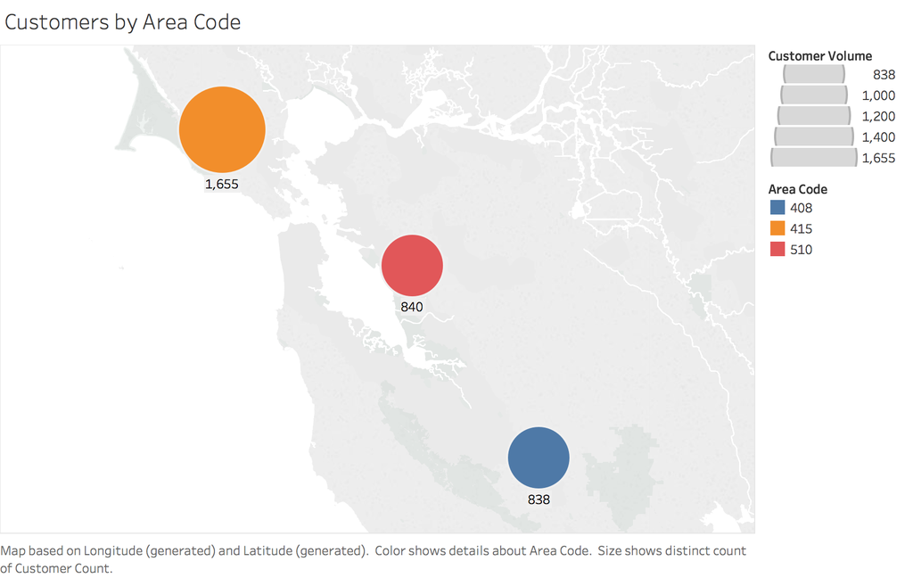

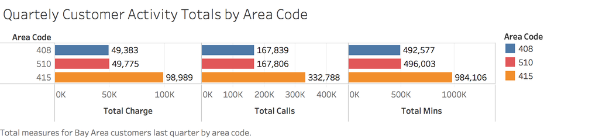

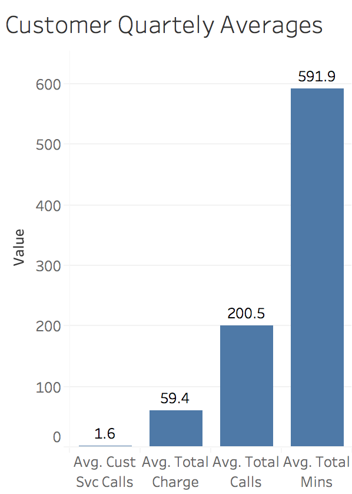

### 0.5.2 Visual analysis of customers that end contracts

**Please refer to the enclosed TWBX file for full Tableau dashboard and worksheets.**

Customers who churn made more customer service calls, was charged more, and spent more time on calls.

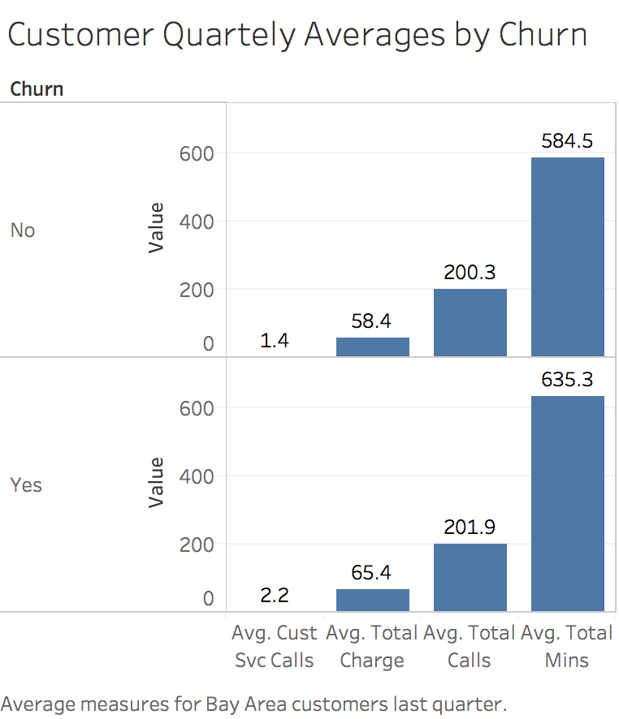

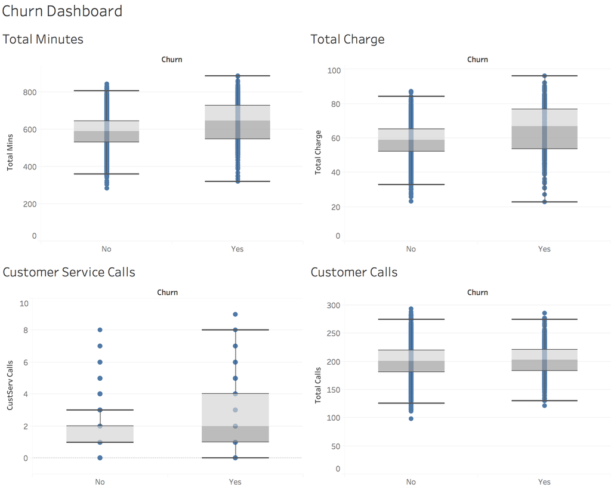

## 0.6 Predictive Models

Split the customer activity data into training and test sets

```r
library(caTools)

set.seed(3000)
spl = sample.split(customer_activity$Churn, SplitRatio = 0.7)
Train = subset(customer_activity, spl==TRUE)
Test = subset(customer_activity, spl==FALSE)
```

### 0.6.1 Logistic Regression

For simplicity of the model, I chose the high-level aggregations for my independent variables.

```r
churnLog = glm(Churn ~ VMail_Message + Total_Mins + Total_Charge + Total_Calls
               + CustServ_Calls + Intl_Plan + VMail_Plan
               , data = Train, family=binomial)

summary(churnLog)
```

```
##
## Call:
## glm(formula = Churn ~ VMail_Message + Total_Mins + Total_Charge +
##     Total_Calls + CustServ_Calls + Intl_Plan + VMail_Plan, family = binomial,
##     data = Train)
##
## Deviance Residuals:
##     Min       1Q   Median       3Q      Max
## -2.0797  -0.5118  -0.3326  -0.1784   2.9395
##
## Coefficients:
##                  Estimate Std. Error z value Pr(>|z|)
## (Intercept)    -8.2872195  0.7864931 -10.537  < 2e-16 ***
## VMail_Message   0.0555087  0.0242851   2.286 0.022271 *
## Total_Mins      0.0001366  0.0016677   0.082 0.934709
## Total_Charge    0.0860628  0.0143716   5.988 2.12e-09 ***
## Total_Calls     0.0003323  0.0019053   0.174 0.861561
## CustServ_Calls  0.4886236  0.0472133  10.349  < 2e-16 ***
## Intl_Planyes    2.0433170  0.1767348  11.561  < 2e-16 ***
## VMail_Planyes  -2.9588502  0.7930371  -3.731 0.000191 ***
## ---
## Signif. codes:  0 '***' 0.001 '**' 0.01 '*' 0.05 '.' 0.1 ' ' 1
##
## (Dispersion parameter for binomial family taken to be 1)
##
##     Null deviance: 1930.4  on 2332  degrees of freedom
## Residual deviance: 1491.3  on 2325  degrees of freedom
## AIC: 1507.3
##
## Number of Fisher Scoring iterations: 6
```

Predictions on the test set

```r
predictTest = predict(churnLog, type="response", newdata=Test)
```

Confusion matrix with threshold of 0.5

```r
table(Test$Churn, predictTest > 0.5)
```

```
##
##     FALSE TRUE
##   0   834   21
##   1   121   24
```

```r
(834+24)/(834+24+121+21)
```

```
## [1] 0.858
```

Baseline accuracy; The Logistic model is barely beats baseline.

```r
(834+21)/(834+24+121+21)
```

```
## [1] 0.855
```

However, it has an out of sample AUC of 78%, our model can differentiate between churn and no churn.

```r
library(ROCR)
ROCRpred = prediction(predictTest, Test$Churn)
as.numeric(performance(ROCRpred, "auc")@y.values)
```

```
## [1] 0.7803912
```

Using the Log model to predict churn in new customers dataset.

```r
Churn_predictLog = predict(churnLog, type="response", newdata=new_customers)
new_customer_predictions <- cbind(new_customers, Churn_predictLog)
new_customer_predictions$Churn_predictLog <-ifelse(new_customer_predictions$Churn_predictLog > .51, "1", "0")
new_customer_predictions$Churn_predictLog <- as.factor(new_customer_predictions$Churn_predictLog)
```

### 0.6.2 Classification and Regression Trees

This method builds what is called a tree by splitting on the values of the independent variables. Some advantages of CART are that it does not assume a linear model, like linear or log regression, and it’s a very interpretable model.

```r
library(rpart)
library(rpart.plot)
```

I use the same independent variables for this method.

```r
ChurnTree = rpart(Churn ~ VMail_Message + Total_Mins + Total_Charge + Total_Calls
                   + CustServ_Calls + Intl_Plan + VMail_Plan
                   , data = Train, method="class", minbucket=25)
```

To predict the outcome for a new observation or case, you can follow the splits in the tree and at the end, you predict the most frequent outcome in the training set that followed the same path.

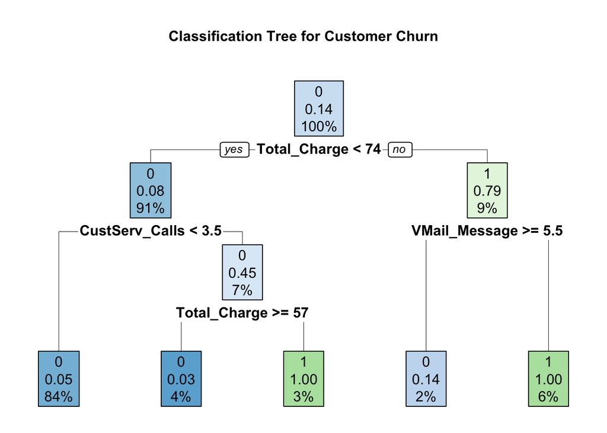

```r
rpart.plot(ChurnTree
           , uniform=TRUE, compress=TRUE
           , fallen=T, branch=1, round=0, cex.main=1
           , split.round=0
           , branch.lwd=.5, split.lwd=.5, nn.lwd=.5
           , main = "Classification Tree for Customer Churn")
```

Make predictions

```r
PredictCART = predict(ChurnTree, newdata = Test, type = "class")
table(Test$Churn, PredictCART)
```

```
##    PredictCART
##       0   1
##   0 855   0
##   1  54  91
```

```r
(855+91)/(855+91+55+0)
```

```
## [1] 0.9450549
```

ROC curve; Tree Model Accuracy = 0.94

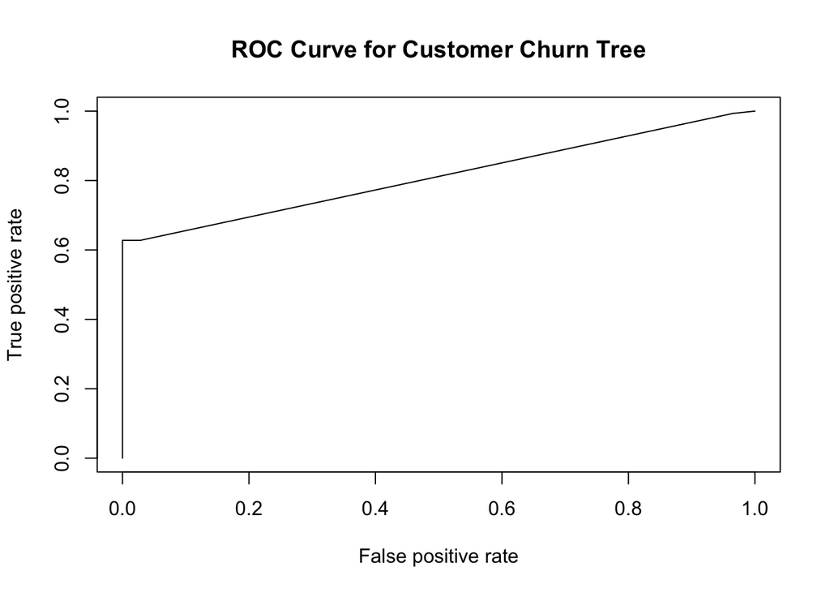

```r
library(ROCR)

PredictROC = predict(ChurnTree, newdata = Test)
PredictROC

pred = prediction(PredictROC[,2], Test$Churn)
perf = performance(pred, "tpr", "fpr")
plot(perf)
title('ROC Curve for Customer Churn Tree')
```

Using the CART model to predict churn in new customers dataset.

```r
Churn_predictTree = predict(ChurnTree, newdata = new_customer_predictions, type = "class")
new_customer_predictions <- cbind(new_customer_predictions, Churn_predictTree)
```

Summary view of appended new customers dataset.

```r
summary(new_customer_predictions)
```

```
##      State      Account_Length     Area_Code          Phone
##  VT     :  50   Min.   :  1.00   Min.   :408.0   327-1319:   1
##  WV     :  50   1st Qu.: 73.00   1st Qu.:415.0   327-3053:   1
##  MN     :  49   Median : 98.00   Median :415.0   327-3587:   1
##  AL     :  44   Mean   : 99.67   Mean   :437.9   327-3850:   1
##  MO     :  44   3rd Qu.:127.00   3rd Qu.:510.0   327-3954:   1
##  AZ     :  43   Max.   :243.00   Max.   :510.0   327-5525:   1
##  (Other):1529                                    (Other) :1803
##  Intl_Plan  VMail_Plan VMail_Message       Day_Mins       Day_Calls
##  no :1631   no :1290   Min.   : 0.000   Min.   :  0.0   Min.   :  0.0
##  yes: 178   yes: 519   1st Qu.: 0.000   1st Qu.:144.9   1st Qu.: 87.0
##                        Median : 0.000   Median :180.0   Median :101.0
##                        Mean   : 8.509   Mean   :180.0   Mean   :100.2
##                        3rd Qu.:21.000   3rd Qu.:216.9   3rd Qu.:113.0
##                        Max.   :51.000   Max.   :350.8   Max.   :165.0
##
##    Day_Charge       Eve_Mins       Eve_Calls       Eve_Charge
##  Min.   : 0.00   Min.   : 31.2   Min.   : 12.0   Min.   : 2.65
##  1st Qu.:24.63   1st Qu.:165.9   1st Qu.: 87.0   1st Qu.:14.10
##  Median :30.60   Median :202.2   Median :101.0   Median :17.19
##  Mean   :30.60   Mean   :200.3   Mean   :100.1   Mean   :17.03
##  3rd Qu.:36.87   3rd Qu.:234.3   3rd Qu.:114.0   3rd Qu.:19.92
##  Max.   :59.64   Max.   :351.6   Max.   :168.0   Max.   :29.89
##
##    Night_Mins     Night_Calls     Night_Charge      Intl_Mins
##  Min.   : 23.2   Min.   : 42.0   Min.   : 1.040   Min.   : 0.0
##  1st Qu.:167.1   1st Qu.: 87.0   1st Qu.: 7.520   1st Qu.: 8.4
##  Median :201.1   Median :101.0   Median : 9.050   Median :10.2
##  Mean   :200.4   Mean   :100.3   Mean   : 9.017   Mean   :10.2
##  3rd Qu.:236.0   3rd Qu.:114.0   3rd Qu.:10.620   3rd Qu.:12.0
##  Max.   :381.9   Max.   :175.0   Max.   :17.190   Max.   :20.0
##
##    Total_Mins      Intl_Calls      Intl_Charge     Total_Charge
##  Min.   :284.3   Min.   : 0.000   Min.   :0.000   Min.   :22.93
##  1st Qu.:529.3   1st Qu.: 3.000   1st Qu.:2.270   1st Qu.:52.48
##  Median :594.1   Median : 4.000   Median :2.750   Median :59.41
##  Mean   :591.0   Mean   : 4.502   Mean   :2.754   Mean   :59.40
##  3rd Qu.:650.1   3rd Qu.: 6.000   3rd Qu.:3.240   3rd Qu.:66.39
##  Max.   :885.0   Max.   :19.000   Max.   :5.400   Max.   :96.15
##
##  CustServ_Calls   Churn          Total_Calls    Churn_predictLog
##  Min.   :0.000   Mode:logical   Min.   :191.0   0:1723
##  1st Qu.:1.000   NA's:1809      1st Qu.:283.0   1:  86
##  Median :1.000                  Median :305.0
##  Mean   :1.543                  Mean   :305.1
##  3rd Qu.:2.000                  3rd Qu.:328.0
##  Max.   :9.000                  Max.   :408.0
##
##  Churn_predictTree
##  0:1659
##  1: 150
##
##
##
##
##
```

### 0.6.3 Predicting churn in new customers

Write to CSV for Tableau visualizations

```r
write.csv(new_customer_predictions, file = "new_customer_predictions.csv")
```

**Please refer to the enclosed TWBX file for full Tableau dashboard and worksheets.**

[output not shown]

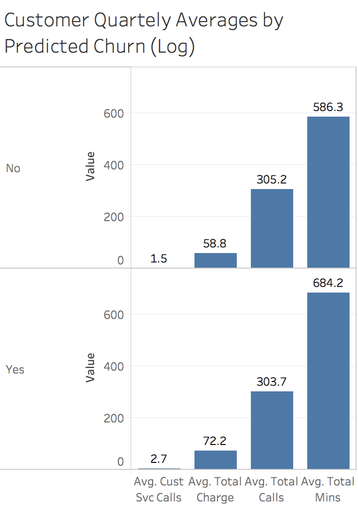

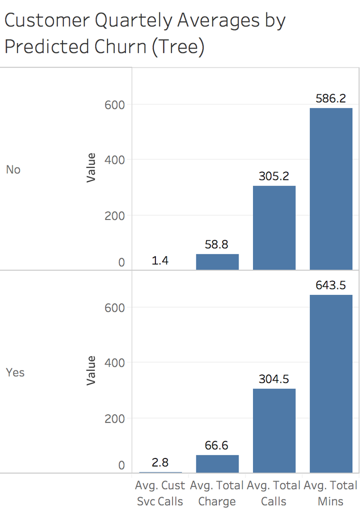

## 0.7 Conclusion

In this analysis, I identified the following variables as significant drivers of customer churn:

Significant variables:

- Customer Service Calls
- Total Charge
- Having an international plan
- Having a voicemail plan
- Voicemail messages

I propose the following next steps:

- Intervention with the customers identified as likely to cancel their account.
- Investigate the root causes of high customer service calls, are the issues these customers facing preventable?
- Investigate the total charges, are customers missing out on promotions?
- Conduct cancellation surveys to identify new variables to begin collecting in customer activity or information datasets.
- Improve the model by collecting data on service quality, could we get our hands on information regarding dropped calls, etc.

[figure not shown]